# Natalie Karavarsamis, PhD

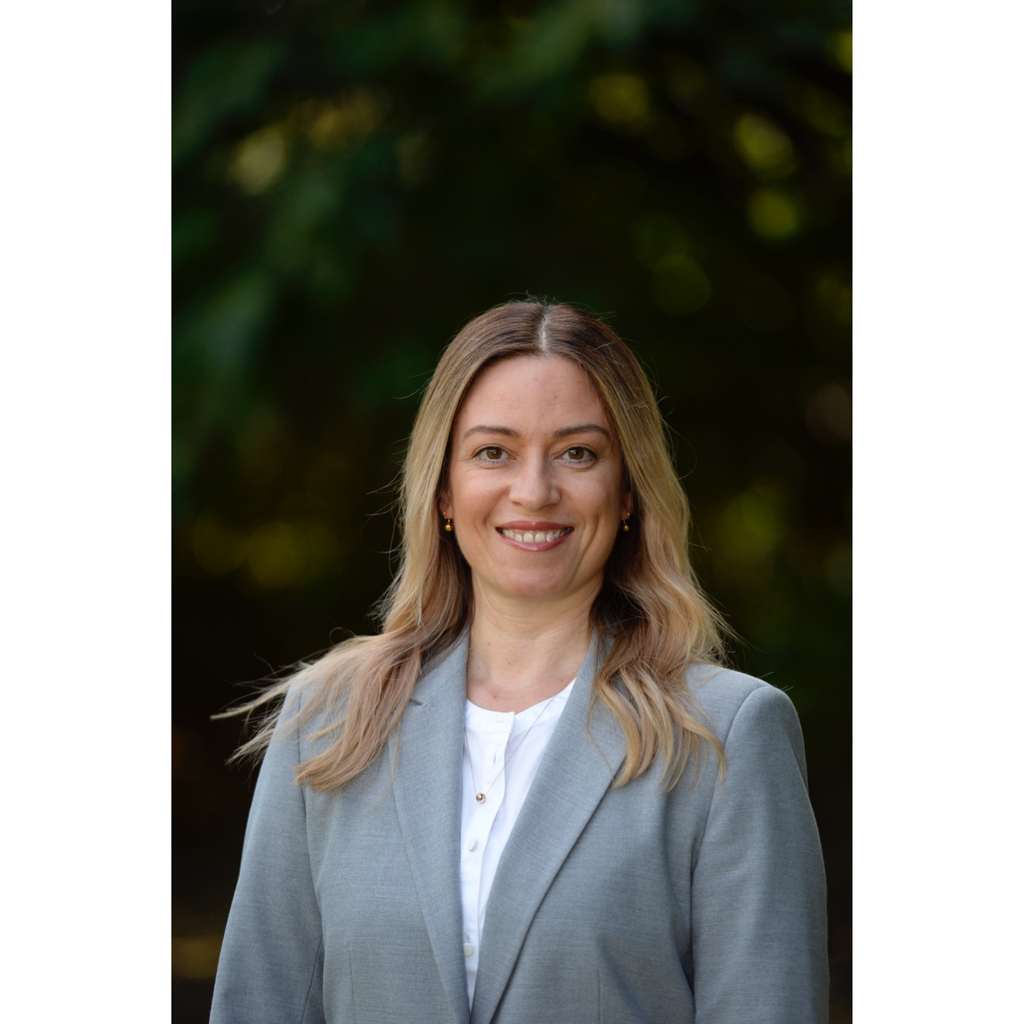

### Academic, Researcher and Data Scientist, Lecturer,

### Professional Statistical Consultant, Computer Programmer

**Curriculum Vitae (CV) including a complete list of publications and presentations: download here.**  
**A description of skills, knowledge, and abilities: download here.**

**Academic Roles**

- Lecturer and Researcher, Department of Mathematics and Statistics, La Trobe University, Melbourne, Australia (2018-2021)
- Lecturer and Researcher, School of Mathematics and Statistics, University of Melbourne, Melbourne, Australia (2016-2018)
- Honorary Research Fellow at University of Melbourne, Australia (2016-2021)
- Technical sub-editor at the Australian and New Zealand Journal of Statistics (2018-2021)
- Reviewer to international scientific peer-reviewed journals (2018-2021)
- Local Organising Committee Member ISEC2020 (2019-2020) http://www.isec2020.org
- Co-chair of RSSDS (2019)

**Professional Roles**

Among other responsibilities, I was statistical (epidemiological) consultant to the departments within the Cancer Council of Victoria (CCV), advising on their research needs in all areas of cancer-related statistics and epidemiology. I was responsible for producing cancer survival rates using the data from the Victorian Cancer Registry as maintained by the CCV.

During my employment at the Department of Primary Industries (DPI) (Victoria, Australia) as a statistician (biometrician), I was a specialist in the design and analysis of complex experiments. I was a state-wide statistical consultant to agricultural and food scientists at DPI as well as external stakeholders. I worked on high-impact national and international projects with industry and government stakeholders (major projects outlined in my CV).

In 2019, I was an invited academic to travel to the Boston Children’s Hospital Research Lab and Department of Neuroscience at Harvard in the US. I visited the wet-lab to consult on the experimental design and analysis of their big-data zebrafish larval studies for new precision medicines to treat childhood epilepsy. As a result, I was a Fulbright finalist for my research proposal into designing and modelling zebrafish studies with high-throughput data for precision medicine for childhood epilepsy. Output from my research on investigating, analysing, and modelling the high-throughput data, were research seminars, and invited speaker presentations at La Trobe University and the Boston Children’s Hospital Research Lab. My knowledge and years of experience in experimental design and cohort studies were invaluable to this research topic.

**Overview**

Dr Natalie Karavarsamis is statistics researcher and consultant, data scientist, coder/programmer, and lecturer. Natalie has been Lecturer and Researcher at the Department of Mathematics and Statistics at La Trobe University and at the School of Mathematics and Statistics, University of Melbourne. Natalie serves as technical sub-editor on the Australian and New Zealand Journal of Statistics, and as reviewer on a number of international peer-reviewed journals, such as, JABE, ANZSTAT, Biometrics, Austral Ecology, Journal of Pediatric Medicine.

Natalie obtained her PhD in Statistics at School of Mathematics and Statistics, University of Melbourne. Prior to completing her PhD Natalie completed a Bachelor of Science Degree and a Bachelor of Science Honours Degree graduating with First Class Honours at University of Melbourne.

Aacademic roles include Lecturer at School of Mathematics and Statistics (University of Melbourne), Postdoctoral Research Fellow at School of Biosciences (University of Melbourne) and with School of Mathematical Sciences (RMIT), and Research Fellow at Department of Food and Land Sciences (prior to PhD candidature) (University of Melbourne).

Natalie’s research expertise is developing new statistical methodology, analysing, and modelling, for statistical ecology, sparse data, large longitudinal biological data, genetic data, neuroscience and epigenetic data, medical statistics and financial data. Demonstrated in Natalie’s extensive publication record in in peer-reviewed journals and books in her roles as research academic, professional statistician and consultant (list of publications in CV).

Natalie is a world leader at developing methods, models and software with modern statistical approaches. For example, for occupancy data with partial likelihoods, conditional and composite likelihoods, GLMs, Gams, IWLS. Circular statistics, cylindrical distributions and HMMs for large biological data. Natalie has developed her own R software package; her two-stage R package for modelling occupancy data (in release).

Natalie has twenty years industry statistical consulting experience and worked on large international industry projects for NGOs, national and international governments, and commercial industries and stakeholders (details in CV).

Natalie has delivered successful statistics courses for more than two decades, at tertiary level (undergraduate and postgraduate), professional level, and private sector (details in CV). Natalie supervises research students; Honours, Masters and PhD candidates in Statistics, Ecology, and Social Sciences, and AMSI scholars (Australian Mathematical Sciences Institute). She has extensive industry training experience in developing and delivering successful workshops, and supervises research assistants, teaching staff, tutors, and students.

**Roles and Responsibilities**

Natalie is academic, researcher, consultant, and educator, who performs in multiple roles with full responsibility that require managing tight and competing deadlines.

She is exprerienced at holding full teaching duties, developing, coordinating and delivery large-scale probability, statistics, and programming undergraduate and postgraduate courses. She is responsible for developing statistical and programming teaching curriculum and material, assessment material and examinations. In addition to managing the online interactive teaching module. Teaching responsibilities involve responding to student queries, providing student consultation and supervising teaching staff. She is examiner and assessor of International Student applications for undergraduate and postgraduate Coursework and Research Science Degrees. She is Examiner of Honours, Masters and PhD theses. She is Science Course Advisor for Mathematics and Statistics, career advisor and student mentor. Committee member, organiser and speaker for O-week (orientation and welcome of new tertiary students). Supervisor of research students for Honours, Masters and PhD candidates. Outreach duties include ambassador for STEMM subjects and careers, as speaker for secondary college students, and tertiary students.

In her role as researcher, she manages deadlines associated with research and developing new statistical methodologies and submissions to peer-reviewed journal articles, as sole author, first author and/or co-author in a team of collaborators, and responds to their queries. She has experience preparing grant submissions. She has served as reviewer and technical sub-editor international peer-reviewed journals. She has expereince hosting overseas academic guests, at organising and co-chairing conferences and academic/professional workshops, and travels as invited academic guest and speaker for her research to nationally and internationally.

**Events**

- June 22–26, 2020. Local organising committe member and accepted speaker. International Statistical Ecology Conference, ISEC2020 , UNSW, Sydney, Australia http://www.isec2020.org
- November 2019. Invited Speaker, Department of Neuroscience and Boston Children’s Hospital, **Harvard University**, USA
- November 2019. Invited Speaker, **INRIA Statistics Seminar Series**, Grenoble, France
- October 18, 2019. Invited Speaker, **Monash Seminar Series**, Monash University, Melbourne, Australia
- October 3, 2019. Invited Speaker, **RMIT Data Analystics Seminar Series** (slides here)
- October 7, 2019. Invited Speaker, **Subject Selection Fair 2019**, La Trobe University, Melbourne, Australia
- August 29, 2019. Organising committee member and Invited Speaker. **Women in Maths Day**, University of Melbourne, Melbourne, Australia
- July 24–26, 2019. Invited Speaker and co-Chair, **Workshop for Research School on Statistics and Data Science 2019 - RSSDS2019**, La Trobe University, Melbourne, Australia. Topics include Statistics, Data Science and allied fields such as AI and Machine Learning are invited to register. Workshop proceedings published in **Springer Communications in Computer and Information Science (CCIS)**. ([webpage](https://sites.google.com/view/rssds2019/home) and poster). My slides here
- June 25-27, 2019. Conference Presenter, **EcoSta2019** Conference. National Chung Hsing University, Taiwan ([conference webpage](http://cmstatistics.org/EcoSta2019/index.php))
- June 19, 2019. Invited Speaker, **AMSI Choose Maths Day**, La Trobe University, Melbourne, Australia
- June 5, 2019. Speaker Joint Seminar, **Special seminar joint La Trobe University & Harvard University**, La Trobe University, Melbourne, Australia
- May 15, 2019. Q&A panel discussion speaker for celebrations for the inaugural **International Women in Mathematics Day**, in honour of the birthday of Maryam Mirzakhani on 12 May, the first female Fields Medalist (poster)
- December 2018. Chair - Statistics Session, AMSI Summer Scholar Conference, University of Melbourne.
- December 2018. Invited Speaker, AMSI Summer Scholar Conference, University of Melbourne.
- November 2018. Supervisor, AMSI Summer Scholar Conference, University of Melbourne.
- July 24 2018. Invited Speaker, **La Trobe – Kyushu joint seminar series**, La Trobe University, Melbourne, Australia and Kyushu University, Japan (via zoom) (slides here)
- July 4-6 2018. Conference Presentation, **ISEC 2018**, St Andrews University, Scotland (slides here)

**Publications**

List in my CV – click here to download

**Supervision**

- Two PhD candidates - Co-supervisor (2018–2021)
- Two AMSI Summer Scholars - Supervisor (2018–2019)

Available for Honours, Masters and PhD supervision.

**Grants & Awards** (selected)

- Fulbright finalist, 2019.
- Early Researcher Establishment Grant, School of Mathematics and Statistics, University of Melbourne (2016–2021).
- Australian-French Association for Research and Innovation (AFRAN) (2018–2021).
- Statify (previously MISTIS) invited academic travel grant (2019).
- Academic Travel Grant, La Trobe University (2019).

**Press & Gallery**